# (Ford GoBike System Data)

## by (George Zaki)

## Preliminary Wrangling

> This data set includes information about individual rides made in a bike-sharing system covering the greater San Francisco Bay area.

### What is the structure of your dataset?

> After Cleaning the dataset now it has only 8 columns with more useful features for data analysis.
> - Member related:
>   - Type (casual or subscriber)
>   - Age
>   - Gender
- Trip related:
  - The Hour of the day
  - The Day
  - Duration in minutes
  - Distance in mile

### What features in the dataset do you think will help support your investigation into your feature(s) of interest?

> I think the day and hour will help us to understand when it's the right time to make offers, also the age and gender is important to know who is our targeted audience.

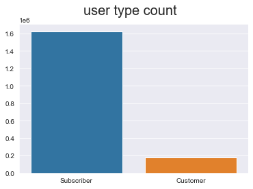

> Here the plot shows that most of the customers are subscribers.

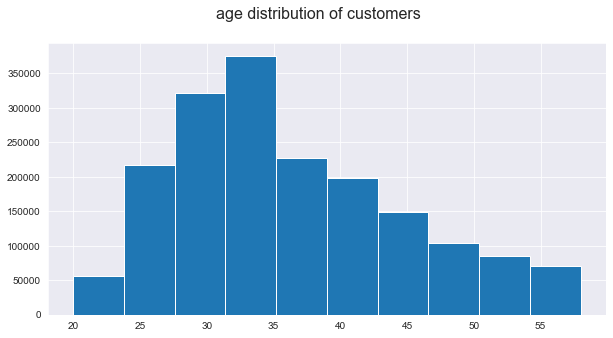

> The Age has a right skewed distribution with the peak age between 25 and 40.

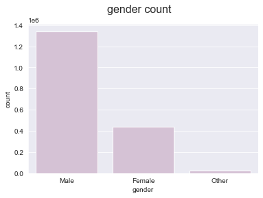

> Most of the custmers are Males.

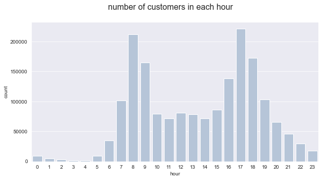

> The customers prefer using bikes either between 7-10 Am or 4-7 PM.

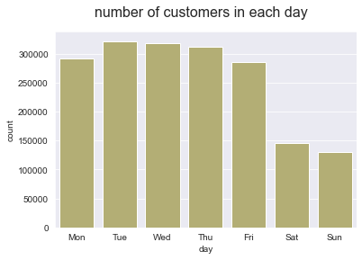

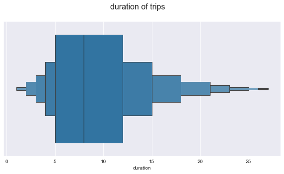

> Most trips usually takes less than 20 minutes.

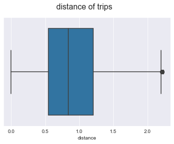

The distance is usually less than 1.5 miles.

### Discuss the distribution(s) of your variable(s) of interest. Were there any unusual points? Did you need to perform any transformations?

> The distriution of the distance and age is right skewed with some outliers so I had to set the xlim to 1.5 IQR to have a better visualizasion.

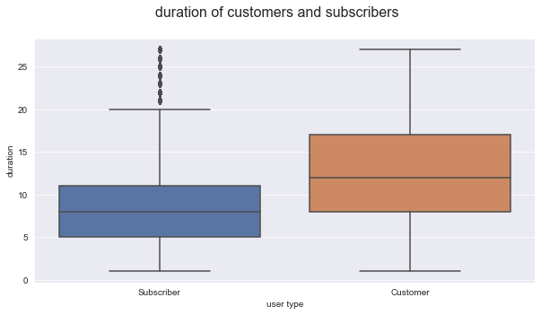

> Customers usually spend more time than subscribers.

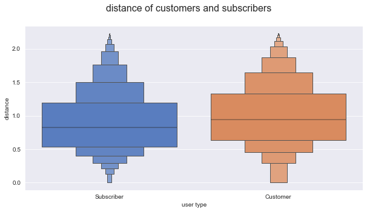

> On average casual customers use bikes for longer distances than subscribers.

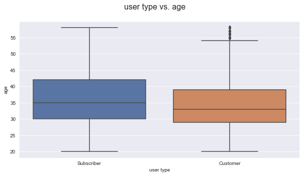

> On average customeers tend to be younger than subscribers.

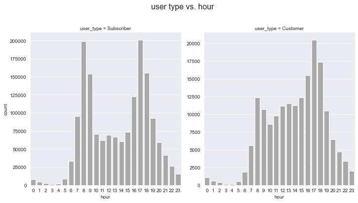

> Both customers and subscribers prefer 7-10 AM and 4-7 PM hours, but the casual customers tend to prefer evening hours more than morning hours.

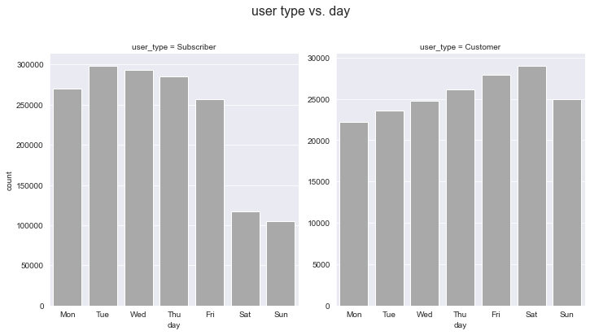

> subscribers tend to use bikes more on weekdays than weekends.

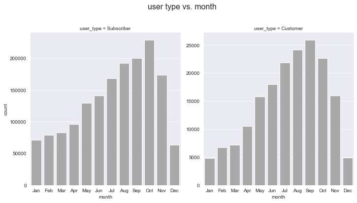

> highest usage of bikes during August-October in general.

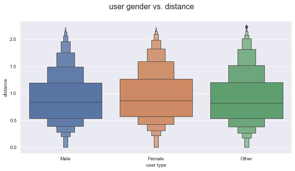

> Feales travel the longest distance.

### Talk about some of the relationships you observed in this part of the investigation. How did the feature(s) of interest vary with other features in the dataset?

> The customers tend to use bikes for longer distances and more time than subscribers. also subscribers use bikes on weekdays more than weekends, which indicates that subscribers use bikes to commute to job or school unlike customers who want to enjoy a ride around the bay area.

### Did you observe any interesting relationships between the other features (not the main feature(s) of interest)?

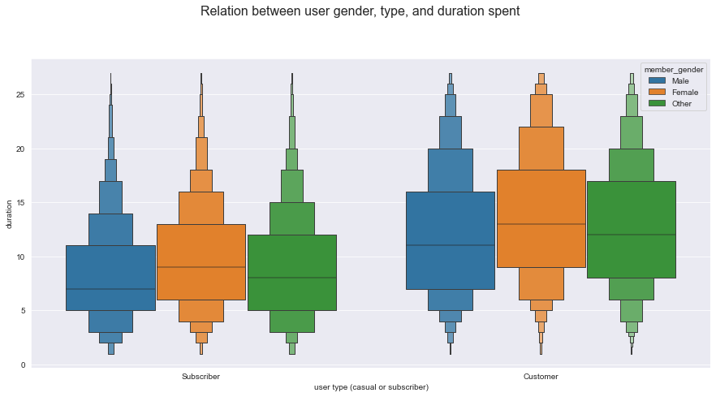

> the data shows that females spend more time in general than other genders.

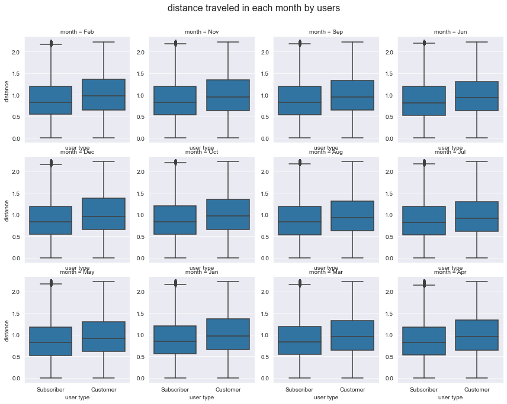

> customers travel more distance than subscribers in all months.

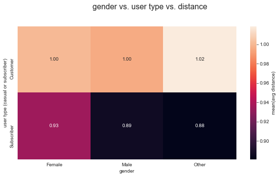

> data shows that casual customers of other gender spend travel more distance on average even though females travel longer distances.

### Talk about some of the relationships you observed in this part of the investigation. Were there features that strengthened each other in terms of looking at your feature(s) of interest?

The multivariable visulization proved the relation between variables:

- that customers travel longer distance than subscribers.
- the female travel more distance in genreal than other genders.
- customers spend more duration on average than subscribers.
- customers prefer the weekends more than subscribers.
- the peak of bike usage happens in october.

### Were there any interesting or surprising interactions between features?

data showed that casual customers of other gender spend travel more distance on average even though females travel longer distances.